# BerlinI_HW3_Wrangling_practice

Author

Ilana Berlin

Published

September 26, 2025

```r
library(tidyverse)
library(readxl)
library(gt)

astronauts <-read_excel("astronauts.xlsx")
scooby <-read_excel("scooby.xlsx")
```

### Problem 1

Obtain rankings of the five astronauts with the most total EVA (extra-vehicular activity) hours. Generate an attractive horizontal bar chart of the results.

```r
astronauts_eva <- astronauts %>%
  group_by(name) %>% #assumes that no two astronauts have the same name
  summarize(eva_total = sum(eva_hrs_mission)) %>%
  slice_max(order_by = eva_total,
            n = 5)

astronauts_eva %>%
  gt() %>%
  tab_header(title = "Highest EVA Hours",
             subtitle = "Top 5 as of 2019")
```

Highest EVA Hours

Top 5 as of 2019

| name | eva_total |
| --- | --- |
| Solovyev, Anatoly | 132.79 |
| Lopez-Alegria, Michael E. | 67.67 |
| Feustel, Andrew J. | 61.80 |
| Whitson, Peggy A. | 60.31 |
| Yurchikhin, Fyodor | 59.43 |

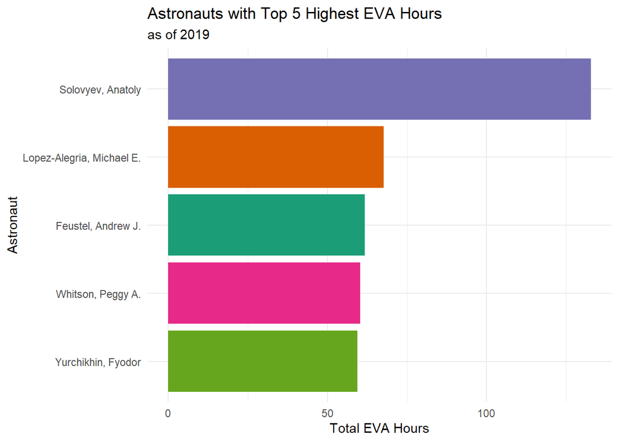

```r
astronauts_eva %>% ggplot(aes(x = eva_total,
             y  = fct_reorder(name, eva_total),
             fill = name
             )) +
  geom_col(show.legend = FALSE) +
  labs(y = "Astronaut",
       x = "Total EVA Hours",
       fill = none,
       title = "Astronauts with Top 5 Highest EVA Hours",
       subtitle = "as of 2019") +
  theme_minimal() +
  scale_fill_brewer(palette = "Dark2")
```

### Problem 2

What are the top five occupations of astronauts? Compute the minimum, median, and maximum ages of astronauts in each of these roles. Also include the total number of times astronauts have had these occupations.

```r
astronauts %>%
  mutate(age = year_of_mission - year_of_birth,
         occupation = tolower(occupation)) %>% #can also use `case_when` for a general is-else
  group_by(occupation) %>%
  summarise(count = n(),
            min_age = min(age),
            median_age = median(age),
            max_age = max(age))%>%
  arrange(desc(count)) %>%
  head(n = 5) %>%
  gt() %>%
  tab_header(title = "Most Common Astronaut Occupations")
```

Most Common Astronaut Occupations

| occupation | count | min_age | median_age | max_age |
| --- | --- | --- | --- | --- |
| msp | 498 | 27 | 42 | 61 |
| commander | 315 | 31 | 44 | 60 |
| pilot | 197 | 26 | 40 | 55 |
| flight engineer | 196 | 30 | 43 | 60 |
| psp | 59 | 29 | 42 | 77 |

### Problem 3

Are civilians less likely to put in EVA hours than military members? Has this changed over time? Obtain a single data frame showing total EVA hours for each year and military/civilian status. Rather than printing the entire thing in your document, create a neat table showing the first 10 rows only. Use the complete table to generate a relevant line plot.

```r
mil_civ_eva <- astronauts %>%
  group_by(year_of_mission,
           military_civilian
           ) %>%
  summarise(total_eva_hours = sum(eva_hrs_mission)) %>%
  ungroup() #get warning if result still has group in it

mil_civ_eva %>%
  head(n = 10) %>%
  gt() %>%
    tab_header(title = "Military and Civilian EVA Hours",
               subtitle = "In the first 10 years")
```

Military and Civilian EVA Hours

| year_of_mission | military_civilian | total_eva_hours |
| --- | --- | --- |
| 1961 | military | 0.00 |
| 1962 | military | 0.00 |
| 1963 | military | 0.00 |
| 1964 | civilian | 0.00 |
| 1964 | military | 0.00 |
| 1965 | military | 1.06 |
| 1966 | civilian | 1.47 |
| 1966 | military | 7.62 |
| 1967 | military | 0.00 |
| 1968 | civilian | 0.00 |

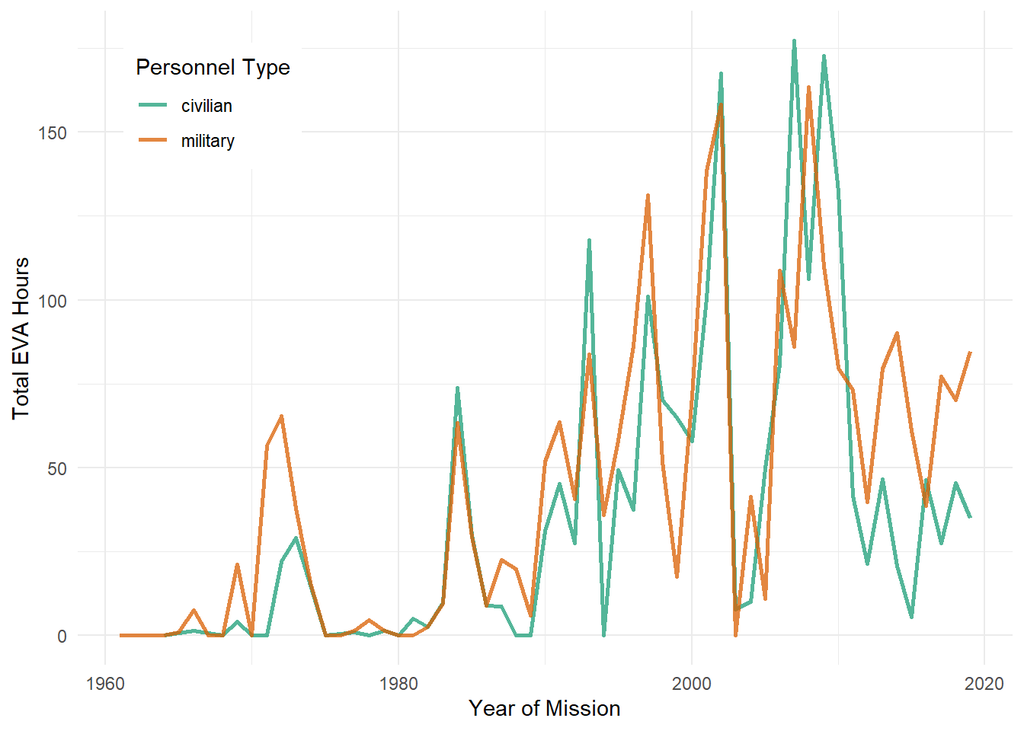

```r
mil_civ_eva %>%
  ggplot(aes(x = year_of_mission,
             y = total_eva_hours,
             group = military_civilian,
             color = military_civilian)) +
  geom_line(linewidth = 1,
            alpha = 0.75) +
  scale_color_brewer(palette = "Dark2") +
  theme_minimal() +
  labs(x = "Year of Mission",
       y = "Total EVA Hours",
       color = "Personnel Type") +
   theme(
    legend.position = "inside",
    legend.position.inside = c(.05,
                               .95),
    legend.justification = c("left",
                             "top"),
    legend.box.background = element_rect(color="white"))
```

### Problem 4

Revisit the scooby data set. Explore the relationship between setting_terrain and one or more other variables in the set until you find something that might be interesting. Include a plot, a numerical summary (like a table), and a short paragraph explaining your findings.

```r
scooby_setting_count <- scooby %>%
  group_by(setting_terrain) %>%
  summarize(count = n(),
            ave_rating = mean(imdb,
                              na.rm = TRUE))
scooby_setting_count %>%
  arrange(count) %>%
  gt() %>%
  tab_header(title = "Average Rating of Scooby-Doo Settings and Their Frequency",
             subtitle = "From Least to Most Frequent")
```

Average Rating of Scooby-Doo Settings and Their Frequency

From Least to Most Frequent

| setting_terrain | count | ave_rating |
| --- | --- | --- |
| Air | 1 | 7.800000 |
| Moon | 1 | 6.800000 |
| Space | 5 | 7.180000 |
| Mountain | 7 | 7.400000 |
| Cave | 9 | 7.644444 |
| Ocean | 12 | 7.225000 |
| Swamp | 12 | 7.475000 |
| Jungle | 15 | 7.080000 |
| Coast | 16 | 7.406250 |
| Island | 21 | 7.371429 |
| Snow | 25 | 7.312500 |
| Desert | 34 | 7.175758 |
| Forest | 45 | 7.445455 |
| Rural | 98 | 7.358947 |
| Urban | 248 | 7.357500 |

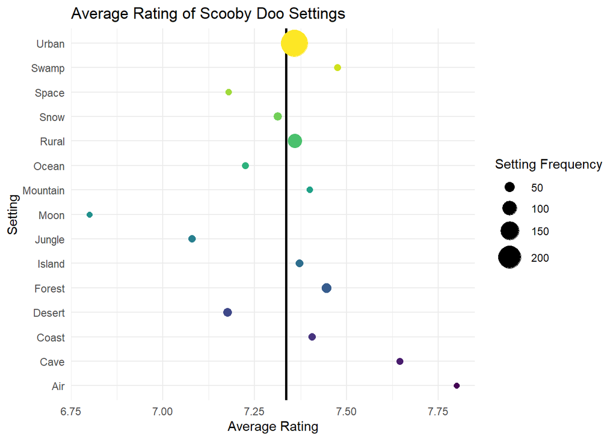

```r
scooby_setting_count %>%
  ggplot(aes(y = setting_terrain,
             x = ave_rating,
             size = count,
             color = setting_terrain)) +
  geom_vline(aes(xintercept = mean(ave_rating),
                 ),
             linewidth = 1) +
  geom_point() +
  labs(x = "Average Rating",
       y = "Setting",
       size = "Setting Frequency",
       title = "Average Rating of Scooby Doo Settings") +
  theme_minimal()+
  scale_color_viridis_d(guide="none") +
   scale_radius(range = c(2,10))
```

Setting that are more common have an average rating closer to the average rating of all Scooby-Doo episodes. For less common setting, high score or low scores can have a larger affect on the average then they can in setting with a higher count. 15 data points were missing imdb scores which should be looked into.